# Lecture 3 (POLS 3316: Statistics for Political Science, Summer 2022)

Tom Hanna

```r
library(tidyverse)
```

## Descriptive Statistics

### Why do we use descriptive statistics?

- Explore the data
- See patterns in the data
- Communicate about the data

### What are the most basic things we need to know?

- What is the scope of the data (time, geography, cases)?
- What are the variables?
- What is the unit of observation?

**Example**

“This data set provides information on the fate of passengers on the fatal maiden voyage of the ocean liner ‘Titanic’, summarized according to economic status (class), sex, age and survival.”

```r
titanic_data <- as.data.frame(Titanic)

head(titanic_data)
```

|  | Class | Sex | Age | Survived | Freq |
| --- | --- | --- | --- | --- | --- |
| 1 | 1st | Male | Child | No | 0 |
| 2 | 2nd | Male | Child | No | 0 |
| 3 | 3rd | Male | Child | No | 35 |
| 4 | Crew | Male | Child | No | 0 |
| 5 | 1st | Female | Child | No | 0 |
| 6 | 2nd | Female | Child | No | 0 |

```r
NA
```

This data is formatted the way we typically like to use data:

- units of observation: rows
- variables: columns

**BEWARE! Not all data is formatted this way!** Sometimes you have to think “is this a variable or a unit of observation?”

For example data is often presented with variables as rows and units of observation as columns. That’s the easy case.

Sometimes, we get data in a mixed format called *wide format*. For example, the following data on Scandinavian temperatures:

```r
# From https://sejdemyr.github.io/r-tutorials/basics/wide-and-long/
# created by SIMON EJDEMYR

# Create long dataset
country_long <- data.frame(
    expand.grid(country = c("Sweden", "Denmark", "Norway"), year = 1994:1996),
    avgtemp = round(runif(9, 3, 12), 0)
    )

# Create wide dataset
country_wide <- data.frame(
    country = c("Sweden", "Denmark", "Norway"),
    avgtemp.1994 = country_long$avgtemp[1:3],
    avgtemp.1995 = country_long$avgtemp[4:6],
    avgtemp.1996 = country_long$avgtemp[7:9])
country_wide
```

| country | avgtemp.1994 | avgtemp.1995 | avgtemp.1996 |
| --- | --- | --- | --- |
| Sweden | 9 | 5 | 3 |
| Denmark | 6 | 11 | 5 |
| Norway | 6 | 7 | 5 |

```r
NA
```

It looks like the unit of observation is country and the variable is a combination of year and temperature.

If we look at it in the long format we are used to, it’s a little clearer:

```r
country_long
```

| country | year | avgtemp |
| --- | --- | --- |
| Sweden | 1994 | 9 |
| Denmark | 1994 | 6 |
| Norway | 1994 | 6 |
| Sweden | 1995 | 5 |
| Denmark | 1995 | 11 |
| Norway | 1995 | 7 |
| Sweden | 1996 | 3 |
| Denmark | 1996 | 5 |
| Norway | 1996 | 5 |

```r
NA
```

The variable is average temperature.

The unit of observation is actually not country - it’s country-year. Sweden-1994 is one observation, Sweden-1995 is a different observation, and Sweden-1996 is a different observation all with different temperature values.

### Measures of Central Tendency

Measures of central tendency help us:

- reveal patterns
- find the typical measurement
- find the center

**A few numbers that can summarize the center of measurement**

- Mean
- Median
- Mode

### Mean

- Symbol: $\bar{x}$
- Not the middle value
- Not the most common
- The center of mass - the sum above equals the sum below
- Formula is $\bar{x} = \frac{\sum X_i}{n}$
- Read that: The mean of X equals the sum of the observations (i) of X divided by the number (n) of observations.

Examples:

A. What is the mean of 1,5,7,9,10,12,18

```r
A <- c(1,5,7,9,10,12,18)

answer_a1 <- (sum(A)/7)

answer_a2 <- mean(A)

answer_a1
```

```
[1] 8.857143
```

```r
answer_a2
```

```
[1] 8.857143
```

B. What is the mean of 10,20,25,30,35,40,45,50,55

```r
B <- c(10,20,30,35,40,45,50,55,25)

mean_b1 <- (sum(B)/9)

mean_b2 <- mean(B)

mean_b1
```

```
[1] 34.44444
```

```r
mean_b2
```

```
[1] 34.44444
```

### Median

- Midpoint
- Half observations are greater, half are lower
- Just count
- Even observations - midpoint between middle two

Examples:

A - 1,5,7,9,10,12,18

```r
median(A)
```

```
[1] 9
```

B - 10,20,25,30,35,40,45,50,55

```r
median(B)
```

```
[1] 35
```

In both of our examples, the mean and median were close but not the same. That isn’t always the case.

### Mode

- Most common value
- Just count

Examples:

C. 1,2,3,4,4,5,6,7

D. 10,20,30,30,40,40,40,50,50,60,70

### Advantages and disadvantages

- Median isn’t affected by outliers
- Mean gives the broader picture because it includes the outliers.
- Mode is the only option for categorical variables. *We will discuss types of variables a bit when talk about your project data and more later in the semester when we talk about hypothesis testing.*

### Skewed distribution - when mean and median are different

**The three numbers are often different for the same sample or population.**

Example:

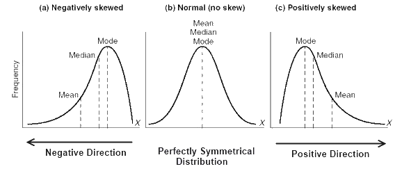

Negatively skewed, Normal, and Positively Skewed distributions

### Discussion: Your Project Data Set

Discussion: Project data set

1. Keep it simple
   1. Fewer variables and fewer observations are better
   2. You don’t need to solve the problem in this class
   3. Try to avoid time series - or be aware of the issues
2. Types of variables a. Continuous Numeric - look for numbers with decimal places b. Binary - avoid c. Categorical - Nominal avoid d. Categorical - Ordinal - avoid e. Numeric discrete - avoid
3. Sources if you don’t have something in mind a. Internal R datasets - https://stat.ethz.ch/R-manual/R-devel/library/datasets/html/00Index.html b. The Dataverse - https://dataverse.org/ c. Example https://www.sciencedirect.com/science/article/pii/S2665963821000762 c. State and federal databases Example: https://cris.dot.state.tx.us/public/Query/app/home d. Kaggle - https://www.kaggle.com/datasets

### Break time! Lab in 10 Minutes!